# ISLML_17307110448_Yunsiyu

Yun Siyu

2019年9月24日

# 乐高数据可视化

## 案例背景

乐高公司于1932年在丹麦创立，至今已有87年的发展历史。其发行的玩具套装构思惊奇、设计巧妙，受到世界各地各个年龄人们的喜爱，可谓是世界上最受欢迎的玩具之一。制作精美的玩具自然在各个环节都精雕细琢——从各个零件的设计及其颜色，再到零件间的搭配从而形成套装，甚至套装亦能互相结合形成新的、更大的套装；而同时，与时俱进的推出新的主题，也是乐高玩具经久不衰的重要原因之一。在本案例当中，我们将从零件到套装、再到主题，对乐高近70年出品的玩具进行分析，一睹乐高玩具世界的炫彩缤纷。

## 数据介绍

本案例所用数据来源于乐高官方网站，包含主题、套装、零件等8个数据集，数据集之间通过变量相互连接。更详细数据介绍见本案例推文：https://mp.weixin.qq.com/s/gc7uy68Gl95GXJHOTTD1VQ

## 学习目标

1. ggplot2绘图
2. 锻炼处理存在复杂关联的数据集的能力
3. 使用tidyverse管道式写法进行数据处理 ##准备工作

```r
#清除工作空间
cat("\014");rm(list=ls())
```

```r
#安装相应软件包
library('ggthemes')
library('plotly');
library('rmarkdown');
library('lubridate');
library('sqldf');
library('dygraphs');
library('reshape2');
library('dplyr');
library('magrittr');
library('scales');
library('ggplot2');
library('foreign');
```

## 任务一:数据读入

1. 读入各个csv文件，并按照文件名进行命名
2. 去掉1949年以前和2019年的数据

```r
colors = read.csv('E:\\学习资料\\大三上\\机器学习概论\\作业\\homework3\\colors.csv');
inventories = read.csv('E:\\学习资料\\大三上\\机器学习概论\\作业\\homework3\\inventories.csv');
inventory_parts = read.csv('E:\\学习资料\\大三上\\机器学习概论\\作业\\homework3\\inventory_parts.csv');
inventory_sets = read.csv('E:\\学习资料\\大三上\\机器学习概论\\作业\\homework3\\inventory_sets.csv');
part_categories = read.csv('E:\\学习资料\\大三上\\机器学习概论\\作业\\homework3\\part_categories.csv');
part_relationships = read.csv('E:\\学习资料\\大三上\\机器学习概论\\作业\\homework3\\part_relationships.csv');
sets = read.csv('E:\\学习资料\\大三上\\机器学习概论\\作业\\homework3\\sets.csv');
themes = read.csv('E:\\学习资料\\大三上\\机器学习概论\\作业\\homework3\\themes.csv')
parts = read.csv('E:\\学习资料\\大三上\\机器学习概论\\作业\\homework3\\parts.csv')
```

```r
#读入数据完成后，利用sqldf包进行选择（变相删除工作）
sets = sqldf("select * from sets where year>=1949 and year<2019")
```

## 数据处理之颜色变量

1. 计算color表中出现过的颜色的数量，将其命名为num_colors
2. 将colors当中的rgb指标在开头增加‘#’，便于稍后绘图时，直接使用rgb录入配色
3. 将颜色的rgb数据单独保存，命名为my_color

```r
#使用unique函数统计出现过的颜色数量
num_colors = length(unique(colors$name))
num_colors
```

```
## [1] 178
```

```r
#首先将rgb类型转化为字符串形式，随后利用paste函数进行字符串的链接
colors$rgb = as.character(colors$rgb)
colors$rgb = paste('#',colors$rgb,sep='')
my_color = colors$rgb
```

## 数据处理

注：本任务主要针对数据集相互关联、生成新数据集，为使用ggplot2绘图准备数据

1. 计算每年套装平均零件数,命名为part_year,包含year、avg_parts两个变量

```r
#使用groupby函数进行分组，使用mean函数求平均
part_year <- sets %>% group_by(year) %>% summarize(avg_parts=mean(num_parts))
head(part_year)
```

```
## # A tibble: 6 x 2
##    year avg_parts
##   <int>     <dbl>
## 1  1949      99.6
## 2  1950       1
## 3  1953      13.5
## 4  1954      12.4
## 5  1955      36.6
## 6  1956      18.9
```

2. 将part_category、parts、colors、themes、sets数据集当中的name变量分别命名为part_category_name、part_name、color_name、theme_name、set_name,便于以后区分

```r
#利用rename函数进行重命名
part_categories <- part_categories %>%  rename(part_category_name = name)
parts=parts %>%  rename(part_name = name)
colors=colors %>%  rename(color_name = name)
themes=themes %>%  rename(theme_name = name)
sets=sets %>%  rename(set_name = name)
```

3. 将零件种类数据集和零件数据集左连接,连接所用变量为part_cat_id，新数据集命名为part_cat

```r
#利用leftjoin函数实现左连接
part_cat <- left_join (part_categories, parts,by=c('id'='part_cat_id'))
head(part_cat)
```

```
##   id part_category_name part_num
## 1  1         Baseplates     0901
## 2  1         Baseplates     0902
## 3  1         Baseplates     0903
## 4  1         Baseplates     0904
## 5  1         Baseplates       10
## 6  1         Baseplates      10a
##                                                part_name
## 1      Baseplate 16 x 30 with Set 080 Yellow House Print
## 2 Baseplate 16 x 24 with Set 080 Small White House Print
## 3         Baseplate 16 x 24 with Set 080 Red House Print
## 4 Baseplate 16 x 24 with Set 080 Large White House Print
## 5                                      Baseplate 24 x 32
## 6                 Baseplate 24 x 32 with Squared Corners
```

4. 将part_cat数据集和零件颜色数据集和零件清单数据集左连接，分别使用变量part_num和id，新数据集命名为part_color

```r
#跟上题一样
part_cat$part_num <- as.character(part_cat$part_num)
inventory_parts$part_num=as.character(inventory_parts$part_num)
part_color_temp <- left_join(part_cat,inventory_parts,by=c('part_num'='part_num'))
part_color <- left_join(part_color_temp,colors,by=c('color_id'='id'))
part_color <- sqldf("select * from part_color where color_id!=9999")
head(part_color)
```

```
##   id part_category_name part_num
## 1  1         Baseplates     0901
## 2  1         Baseplates     0901
## 3  1         Baseplates     0902
## 4  1         Baseplates     0902
## 5  1         Baseplates     0903
## 6  1         Baseplates     0903
##                                                part_name inventory_id
## 1      Baseplate 16 x 30 with Set 080 Yellow House Print         1973
## 2      Baseplate 16 x 30 with Set 080 Yellow House Print        24756
## 3 Baseplate 16 x 24 with Set 080 Small White House Print         1973
## 4 Baseplate 16 x 24 with Set 080 Small White House Print        24756
## 5         Baseplate 16 x 24 with Set 080 Red House Print         1973
## 6         Baseplate 16 x 24 with Set 080 Red House Print        24756
##   color_id quantity is_spare color_name     rgb is_trans
## 1        2        1        f      Green #237841        f
## 2        2        1        f      Green #237841        f
## 3        2        1        f      Green #237841        f
## 4        2        1        f      Green #237841        f
## 5        2        1        f      Green #237841        f
## 6        2        1        f      Green #237841        f
```

5. 计算各颜色在零件当中出现的次数，并按降序排列，同时颜色名称和其rgb一一对应。结果保留在命名为partsp_color的数据集当中，变量分别命名为color_name、rbg、part_per_color

```r
#第五题统计次数考虑用n(),降序排列考虑用decrease
part_n <- part_color[!duplicated(part_color[,c(4,9)]),]
partsp_col <- part_n %>% group_by(color_name,rgb) %>% summarize(part_per_color=n())
#排序
partsp_col <- partsp_col[order(partsp_col$part_per_color,decreasing=T),]
head(partsp_col)
```

```
## # A tibble: 6 x 3
## # Groups:   color_name [6]
##   color_name        rgb     part_per_color
##   <fct>             <chr>            <int>
## 1 White             #FFFFFF           5629
## 2 Black             #05131D           5248
## 3 Yellow            #F2CD37           3743
## 4 Red               #C91A09           3687
## 5 Blue              #0055BF           2294
## 6 Light Bluish Gray #A0A5A9           1884
```

6. 将套装和主题做连接,所用变量为theme_id,新的数据集命名为set_themes

```r
#第六题和第四题第三题一样，只不过结果要去掉全为NA的parent_id.
set_themes <- left_join (themes,sets,by=c('id'='theme_id'))
set_themes <- sqldf("select id, theme_name, set_num,set_name, year, num_parts from set_themes")
head(set_themes)
```

```
##   id theme_name set_num                       set_name year num_parts
## 1  1    Technic   001-1                          Gears 1965        43
## 2  1    Technic   002-1 4.5V Samsonite Gears Motor Set 1965         3
## 3  1    Technic  1030-1 TECHNIC I: Simple Machines Set 1985       191
## 4  1    Technic  1038-1             ERBIE the Robo-Car 1985       120
## 5  1    Technic  1039-1           Manual Control Set 1 1986        39
## 6  1    Technic  1168-1                    Battery Box 1986         1
```

7. 计算不同主题下套装的个数,将新的数据集命名为themes_per_set

```r
#第七题利用groupby函数分组，利用order排序输出
themes_per_set <- set_themes %>% group_by(theme_name) %>% summarize(set_cnt=n())
themes_per_set <- themes_per_set[order(themes_per_set$set_cnt,decreasing=T),];
head(themes_per_set)
```

```
## # A tibble: 6 x 2
##   theme_name   set_cnt
##   <fct>          <int>
## 1 Supplemental     532
## 2 Basic Set        517
## 3 Technic          426
## 4 Gear             351
## 5 Friends          326
## 6 City             319
```

8. 将颜色和套装进行连接

```r
#使用内连接实现，使用sql语句实现表的连接最为方便
inventory_sets$set_num <- as.character(inventory_sets$set_num)
sets$set_num <- as.character(sets$set_num)
set_color1 <- left_join(sets,inventories,by=c('set_num'='set_num'))
set_color2 <- left_join(set_color1,inventory_parts,by=c('id'='inventory_id'))
set_color <- inner_join(set_color2,colors,by=c('color_id'='id'))
head(set_color)
```

```
##   set_num        set_name year theme_id num_parts   id version part_num
## 1    00-1 Weetabix Castle 1970      414       471 5574       1    29c01
## 2    00-1 Weetabix Castle 1970      414       471 5574       1    29c01
## 3    00-1 Weetabix Castle 1970      414       471 5574       1    3001a
## 4    00-1 Weetabix Castle 1970      414       471 5574       1    3001a
## 5    00-1 Weetabix Castle 1970      414       471 5574       1    3001a
## 6    00-1 Weetabix Castle 1970      414       471 5574       1    3002a
##   color_id quantity is_spare color_name     rgb is_trans
## 1        4        8        f        Red #C91A09        f
## 2       15        6        f      White #FFFFFF        f
## 3        1        4        f       Blue #0055BF        f
## 4        4        9        f        Red #C91A09        f
## 5       15       25        f      White #FFFFFF        f
## 6        4        6        f        Red #C91A09        f
```

9. 提取不同颜色的出现年份、使用年数、rgb,储存为scolor

```r
#使用groupby函数进行分组，使用年份可以用现在的年份-起始年份
scolor <- set_color %>% group_by(color_name,rgb) %>% summarize(year=min(year),ys=2019-min(year))
scolor <- scolor[order(scolor$year,decreasing=T),];
head(scolor)
```

```
## # A tibble: 6 x 4
## # Groups:   color_name [6]
##   color_name               rgb      year    ys
##   <fct>                    <chr>   <int> <dbl>
## 1 Glitter Trans-Light Blue #68BCC5  2015     4
## 2 Glitter Trans-Neon Green #C0F500  2015     4
## 3 Olive Green              #9B9A5A  2012     7
## 4 Yellowish Green          #DFEEA5  2012     7
## 5 Dark Azure               #078BC9  2011     8
## 6 Lavender                 #E1D5ED  2011     8
```

## 任务四：绘制主题箱线图

使用sets表中的信息，选取某一个theme_id,对其year与num_parts两列作出箱线图，并给出解读

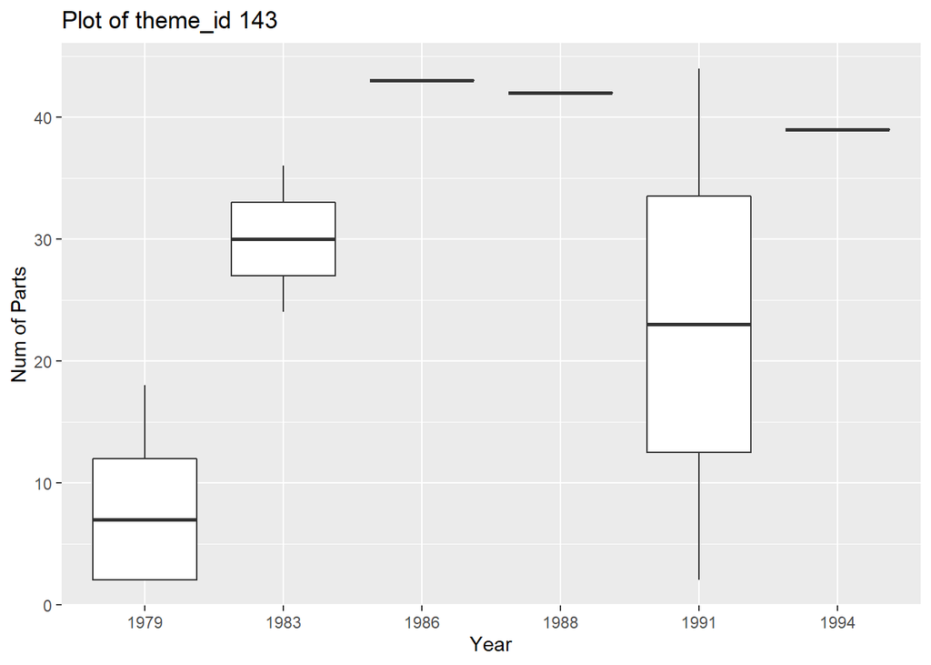

[output not shown]

```r
#使用sqldf选择列表,使用ggplot2包画图
set_one <- sqldf("select year,num_parts from sets where theme_id = 143")
set_one$year <- as.character(set_one$year)
p <- ggplot(data=set_one)
p+geom_boxplot(aes(x=year,y=num_parts))+xlab('Year')+ylab('Num of Parts')+ggtitle('Plot of theme_id 143')
```

## 任务五：绘制主题数量时间序列图

使用sets表中的信息，绘制乐高主题数量时间序列图,并给出解读

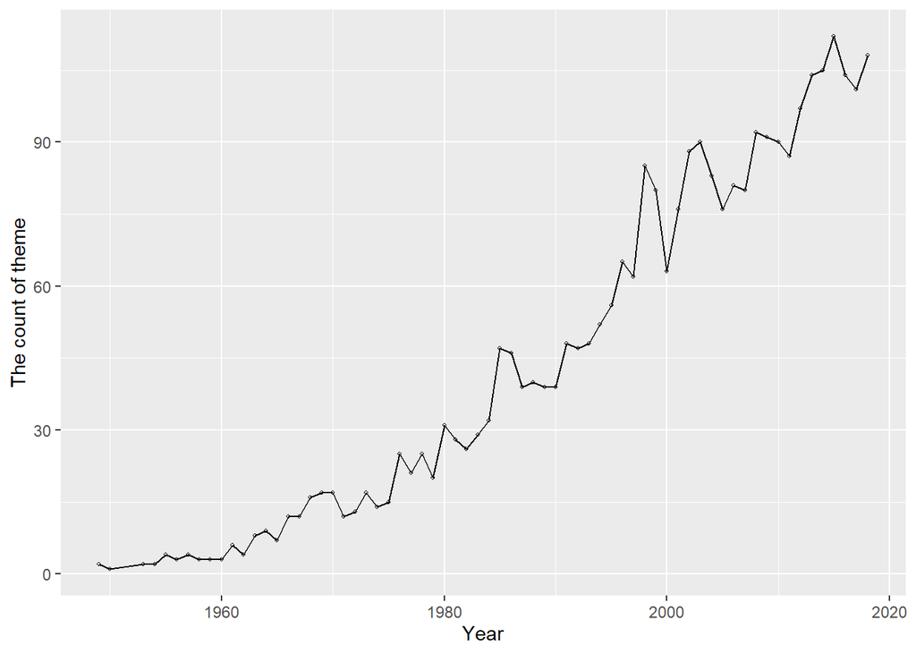

[output not shown]

```r
#首先计算每年的乐高数量，然后画图
legao <- sqldf("select year,theme_id from sets")
#去重
legao <- unique(legao)
#分组
legao_num <- legao %>% group_by(year) %>% summarize(count=n())
p <- ggplot(data=legao_num,mapping=aes(x=year,y=count))
p+geom_line(size=0.5)+geom_point(size=0.8, shape=1)+xlab('Year')+ylab('The count of theme')
```

## 任务六:绘制零件类别所包含零件数量柱状图

使用part_cat表中信息，绘制零件类别所包含零件数量柱状图,并给出解读

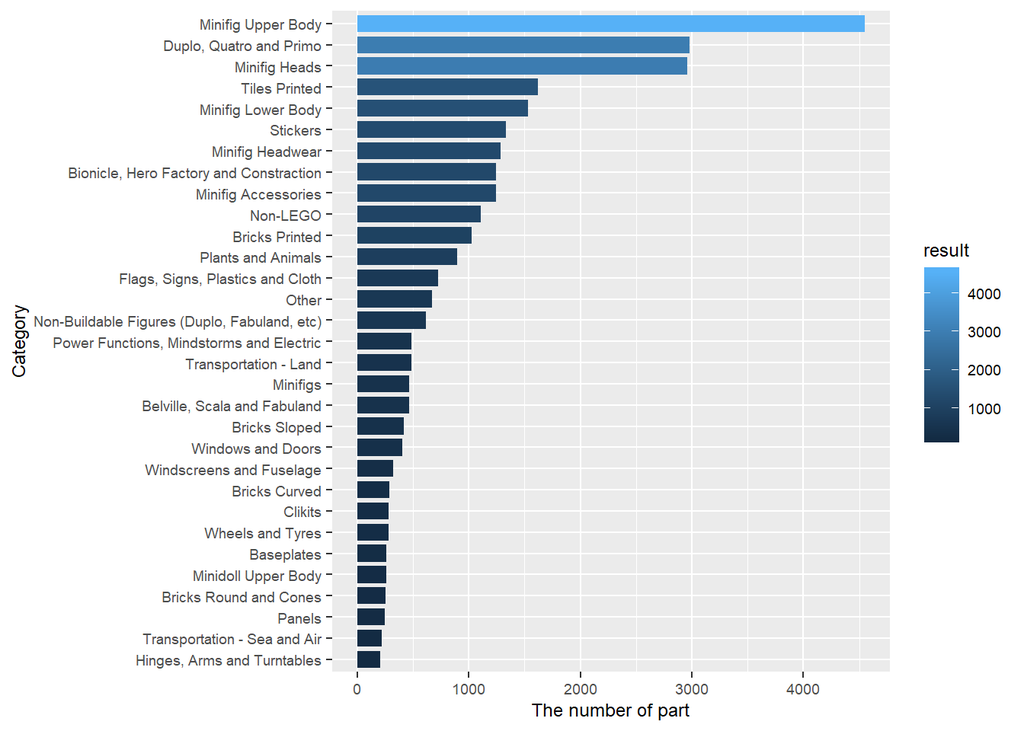

```
 解读：本任务所关心的因变量是零件数量。柱状图可以看出，不同零件类别所对应的零件数量差异较大。其中minifig upper body所含零件数最多，这是由于乐高玩具中有各式各样的人物形象，每一种人物形象都会对应一个人仔（minifig），故而人仔上半身的零件数量远高于其他零件种类。
```

```r
#首先分组统计每个类别的数量，然后画图
c <- sqldf("select part_num,part_category_name from part_cat")
c$part_category_name <- as.character(c$part_category_name)
c_num<-c%>%group_by(part_category_name)%>%summarize(result=n())
#排序
c_num <- c_num[order(c_num$result,decreasing=F),];
#调整level
c_num$part_category_name  <-  factor(c_num$part_category_name,levels=as.vector(c_num$part_category_name))
c_num_top <- c_num %>%  filter(result>200)
p <- ggplot(data=c_num_top,mapping=aes(x=part_category_name,y=result,fill=result))
p+ geom_bar(stat='identity',width=0.8)+xlab('Category')+ylab('The number of part')+ coord_flip()+ theme(text = element_text(size=9))
```

## 任务七：绘制颜色出现次数柱状图、历年颜色出现次数堆积图

使用partsp_col表中数据绘制颜色出现次数柱状图、使用set_color绘制历年颜色出现次数堆积图,并给出解读

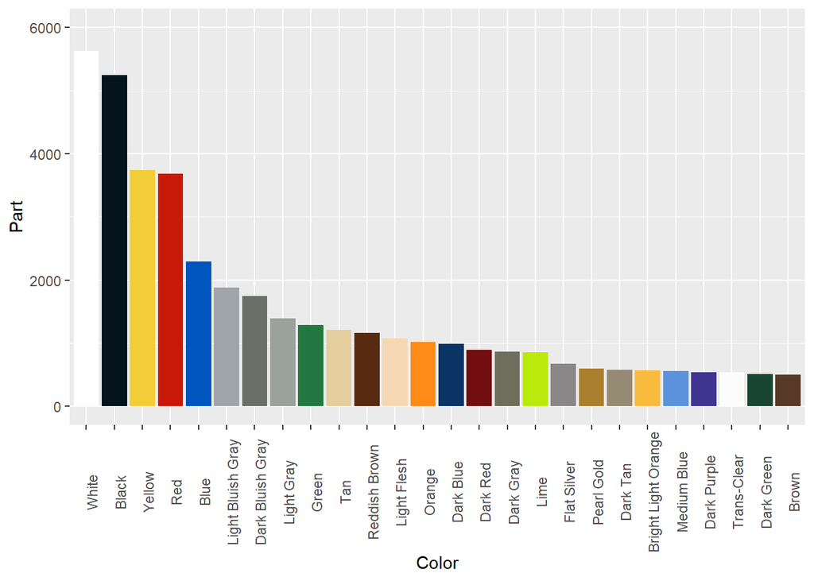

```
 解读：本任务所关心的因变量是每种颜色出现的次数。由柱状图可以看出每种颜色出现次数有较大差异，其中白色和黑色数量较多，这说明乐高玩具的主要配色是黑色和白色。从图中还可以看出，乐高玩具的彩色配色以黄色和红色为多，同时玩具颜色也具有多样性的特点。
```

```r
#先使用sqldf包进行数据清洗，然后进行绘图
d <- sqldf("select color_name,rgb,part_per_color from partsp_col where rgb!='NA' and rgb!='#0033B2'")
#排序
d <- d[order(d$part_per_color,decreasing=T),];
d$color_name  <-  factor(d$color_name,levels=as.vector(d$color_name))
d_num_top <- d %>%  filter(part_per_color>500)
p <- ggplot(data=d_num_top,mapping=aes(x=color_name,y=part_per_color))
p+ geom_bar(stat='identity',width=0.9,fill=as.vector(d_num_top$rgb))+xlab('Color')+ylab('Part')+theme(axis.text.x=element_text(size=rel(1), angle=90))+guides(fill=F)+ylim(0,6000)
```

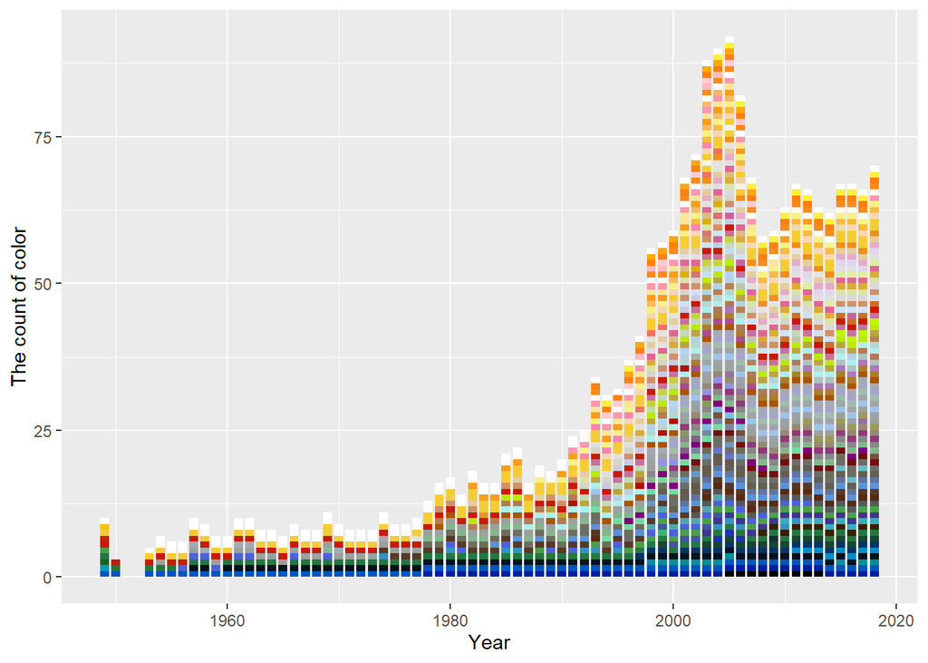

```
解读：本任务所关心的因变量是历年颜色出现次数。从堆积柱状图可以看出，颜色出现次数随年份增加呈现先上升后下降最后平稳的变换。可以推断出乐高公司在2005年之前不断推出新的颜色样式，以实现多彩缤纷的游戏体验。在2005年之后，即使调整淘汰不受欢迎的颜色样式，保留受顾客喜欢的颜色样式，追求给顾客更舒适的游戏体验。在2010年之后颜色样式基本固定。
```

```r
#先使用sqldf包进行数据清洗，然后进行绘图
e <- sqldf("select year,color_name,rgb from set_color where rgb!='#0033B2' and color_id!=9999 ")
e$color_name <- as.character(e$color_name)
#排序
e <- e[order(e$year,decreasing=F),];
e_num <- sqldf("select distinct year,rgb from e")
#分组
e_num <- e_num%>%group_by(year,rgb)%>%summarise(count_color=n())
p <- ggplot(data=e_num,mapping=aes(x=year,y=count_color))
p+ geom_bar(stat='identity',width=0.8,fill=as.vector(e_num$rgb))+xlab('Year')+ylab('The count of color')
```